# Single Heatmap

## Seriation

Seriation is an interesting technique for ordering the matrix (see this interesting post: http://nicolas.kruchten.com/content/2018/02/seriation/). The powerful [**seriation**](https://cran.r-project.org/web/packages/seriation/index.html) package implements quite a lot of methods for seriation. Since it is easy to extract row orders and column ordes from the object returned by the core function `seriate()` from **seriation** package. They can be directly assigned to `row_order` and `column_order` to make the heatmap.

The first example demonstrates to directly apply `seriate()` on the matrix. Since the “BEA_TSP” method only allows a non-negative matrix, we change the matrix to `max(mat) - mat`.

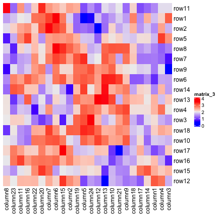

```r
library(seriation)
o = seriate(max(mat) - mat, method = "BEA_TSP")
Heatmap(max(mat) - mat, row_order = get_order(o, 1), column_order = get_order(o, 2))
```

Or apply `seriate()` to the distance matrix. Now the order for rows and columns needs to be calcualted separatedly.

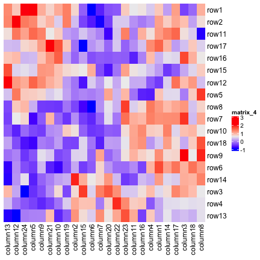

```r
o1 = seriate(dist(mat), method = "TSP")
o2 = seriate(dist(t(mat)), method = "TSP")
Heatmap(mat, row_order = get_order(o1), column_order = get_order(o2))
```

Some seriation methods also contain the hierarchical clustering information. Let's try:

```r
o1 = seriate(dist(mat), method = "GW")
o2 = seriate(dist(t(mat)), method = "GW")
```

`o1` and `o2` are actually mainly composed of `hclust` objects:

```r
class(o1[[1]])
```

```
## [1] "ser_permutation_vector" "hclust"
```

And the orders are the same by using `hclust$order` or `get_order()`.

```r
o1[[1]]$order
```

```
##  [1]  1  2 11 12  5 15 16 17  7  8  6  9 10 18 13  4  3 14
```

```r
# should be the same as the previous one
get_order(o1)
```

```
##  [1]  1  2 11 12  5 15 16 17  7  8  6  9 10 18 13  4  3 14
```

And we can add the dendrograms to the heatmap (note here we turned off the default reordering because we exactly want the dendrogram order returned from seriation).

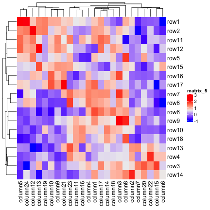

```r
Heatmap(mat, cluster_rows = as.dendrogram(o1[[1]]), row_dend_reorder = FALSE,
    cluster_columns = as.dendrogram(o2[[1]]), column_dend_reorder = FALSE)
```

For more use of the `seriate()` function, please refer to the **seriation** package.

## Dimension names

The row names and column names are drawn on the right and bottom of the heatmap by default. Side, visibility and graphic parameters for dimension names can be set as follows:

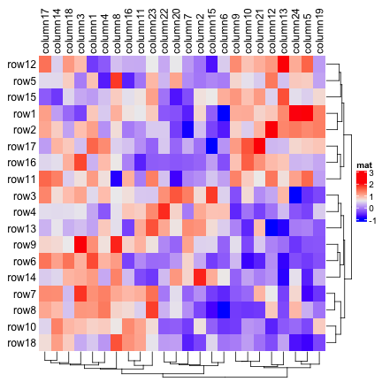

```r
Heatmap(mat, name = "mat", row_names_side = "left", row_dend_side = "right",
    column_names_side = "top", column_dend_side = "bottom")
```

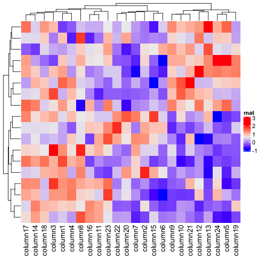

```r
Heatmap(mat, name = "mat", show_row_names = FALSE)
```

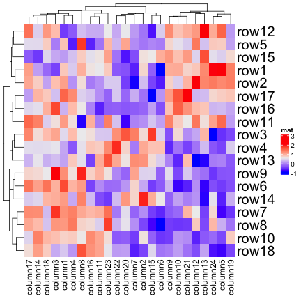

```r
Heatmap(mat, name = "mat", row_names_gp = gpar(fontsize = 20))
```

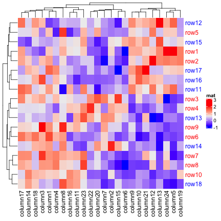

```r
Heatmap(mat, name = "mat", row_names_gp = gpar(col = c(rep("red", 10), rep("blue", 8))))
```

The rotation of column names can be set by `column_names_rot`:

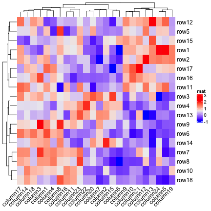

```r
Heatmap(mat, name = "mat", column_names_rot = 45)
```

If you have row names or column names which are too long, `row_names_max_width` or `column_names_max_height` can be used to set the maximal space for them.

Instead of directly using the row/column names from the matrix, you can also provide another character vector which corresponds to the rows or columns and set it by `row_labels` or `column_labels`. This is useful because you don't need to change the dimension names of the matrix to change the labels on the heatmap while you can directly provide the new labels.

There is one typical scenario that `row_labels` and `column_labels` are useful. For the gene expression analysis, we might use Ensembl ID as the gene ID which is used as row names of the gene expression matrix. However, the Ensembl ID is for the indexing of the Ensembl database but not for the human reading. Instead, we would prefer to put gene symbol on the heatmap as the row names which is easier to read. To do this, we only need to assign the corresponding gene symbols to `row_labels`.

Another advantage is `row_labels` or `column_labels` allows duplicated labels, while duplicated row names or column names are not allowed in the matrix.

Following gives a simple example that we put letters as row labels and column labels:

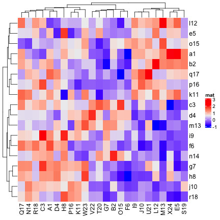

```r
# use named vectors to make sure the correspondance between row names and row labels is correct
row_labels = structure(paste0(letters[1:24], 1:24), names = paste0("row", 1:24))
column_labels = structure(paste0(LETTERS[1:24], 1:24), names = paste0("column", 1:24))
Heatmap(mat, name = "mat", row_labels = row_labels[rownames(mat)],
    column_labels = column_labels[colnames(mat)])
```

One advantage of **ComplexHeatmap** package is it supports splitting the heatmap by rows or/and by columns to better group the features and additionally highlight the patterns.

Following arguments control the splitting: `row_km`, `row_split`, `column_km`, `column_split`. In following, we call the sub-clusters generated by splitting “*slices*”.

### Split by k-means clustering

`row_km` and `column_km` apply k-means partitioning.

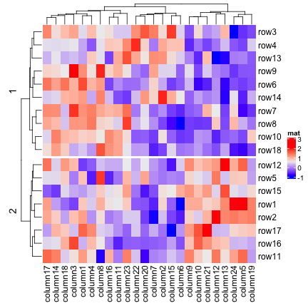

```r
Heatmap(mat, name = "mat", row_km = 2)
```

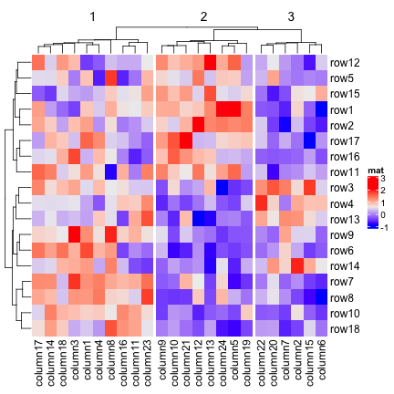

```r
Heatmap(mat, name = "mat", column_km = 3)
```

Row splitting and column splitting can be performed simultaneously.

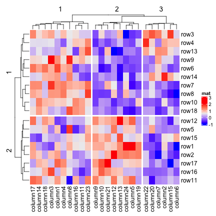

```r
Heatmap(mat, name = "mat", row_km = 2, column_km = 3)
```

### Split by categorical variables

More generally, `row_split` or `column_split` can be set to a categorical vector or a data frame where different combinations of levels split the rows/columns in the heatmap. The order of each slice can be controlled by `levels` of each variable in `split` (in this case, each variable should be a factor). If all variables are characters, the default order is `unique(row_split)` or `unique(column_split)`.

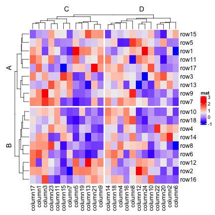

```r
Heatmap(mat, name = "mat", row_split = rep(c("A", "B"), 9), column_split = rep(c("C", "D"), 12))
```

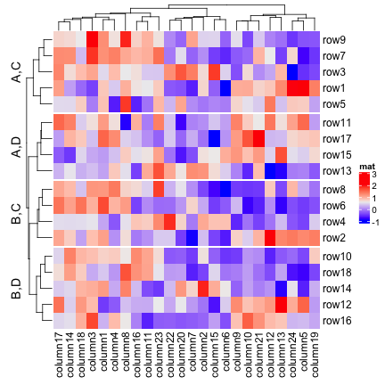

```r
Heatmap(mat, name = "mat", row_split = data.frame(rep(c("A", "B"), 9), rep(c("C", "D"), each = 9)))
```

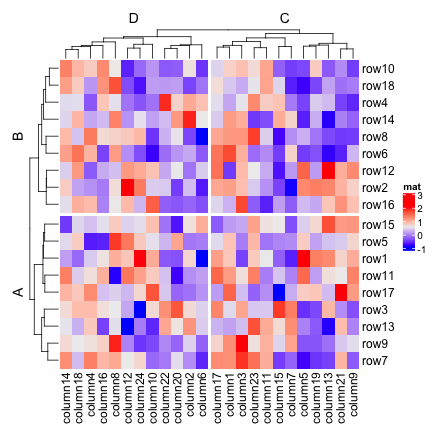

```r
Heatmap(mat, name = "mat", row_split = factor(rep(c("A", "B"), 9), levels = c("B", "A")),
    column_split = factor(rep(c("C", "D"), 12), levels = c("D", "C")))
```

Actually, k-means clustering just generates a vector of cluster classes and appends to `row_split` or `column_split`. `row_km`/`column_km` and be used mixed with `row_split` and `column_split`.

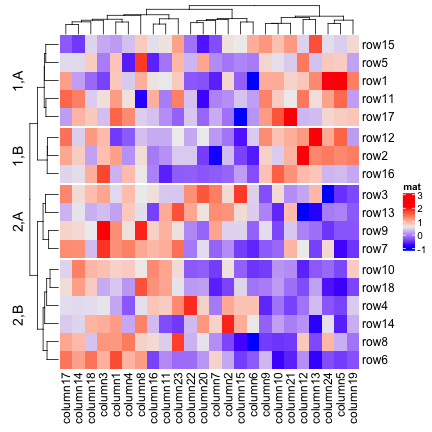

```r
Heatmap(mat, name = "mat", row_split = rep(c("A", "B"), 9), row_km = 2)
```

which is the same as:

```r
# code only for demonstration
cl = kmeans(mat, centers = 2)$cluster
# classes from k-means are always put as the first column in `row_split`
Heatmap(mat, name = "mat", row_split = cbind(cl, rep(c("A", "B"), 9)))
```

If you are not happy with the default k-means partition, it is easy to use other partition methods by just assigning the partition vector to `row_split`/`column_split`.

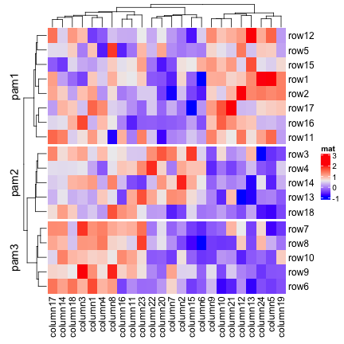

```r
pa = pam(mat, k = 3)
Heatmap(mat, name = "mat", row_split = paste0("pam", pa$clustering))
```

If `row_order` or `column_order` is set, in each row/column slice, it is still ordered.

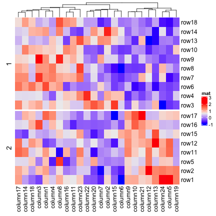

```r
# remember when `row_order` is set, hierarchical clustering on rows is turned off
Heatmap(mat, name = "mat", row_order = 18:1, row_km = 2)
```

Character matrix can only be split by `row_split`/`column_split` argument.

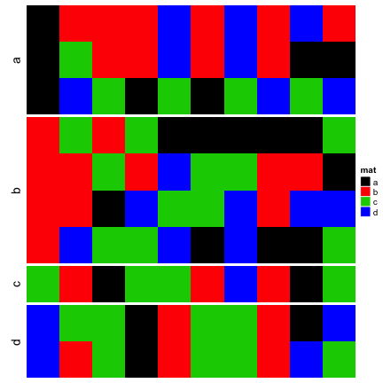

```r
Heatmap(discrete_mat, name = "mat", col = 1:4, row_split = discrete_mat[, 1])
```

### Graphic parameters for splitting

When splitting is applied on rows/columns, graphic parameters for row/column title and row/column names can be specified as same length as number of slices.

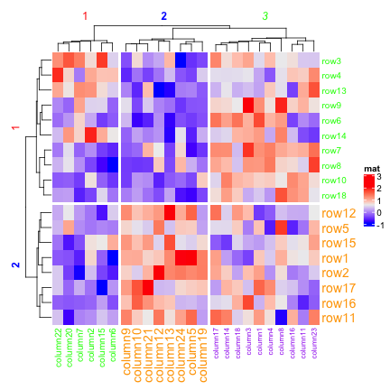

```r
Heatmap(mat, name = "mat",
    row_km = 2, row_title_gp = gpar(col = c("red", "blue"), font = 1:2),
    row_names_gp = gpar(col = c("green", "orange"), fontsize = c(10, 14)),
    column_km = 3, column_title_gp = gpar(col = c("red", "blue", "green"), font = 1:3),
    column_names_gp = gpar(col = c("green", "orange", "purple"), fontsize = c(10, 14, 8)))
```

### Split by dendrogram

In the scenarios described previously, if `row_km`/`column_km` is set or `row_split`/`column_split` is set as a vector or a data frame, hierarchical clustering is first applied to each slice which generates `k` dendrograms, then a parent dendrogram is generated based on the mean value of each slice. **The height of the parent dendrogram is adjusted by adding the maximal height of the dendrograms in all children slices and the parent dendrogram is added on top of the children dendrograms to form a single global dendrogram.**

A second scenario for splitting is that users may still want to keep the global dendrogram which is generated from the complete matrix while not split it in the first place. In this case, `row_split`/`column_split` can be set to a number which will apply `cutree()` on the row/column dendrogram. This works when `cluster_rows`/`cluster_columns` is set to `TRUE` or is assigned with a `hclust`/`dendrogram` object.

For this case, the dendrogram is still as same as the original one, expect the positions of dendrogram leaves are slightly adjusted by the gaps between slices.

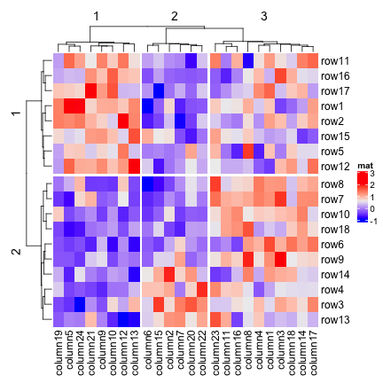

```r
Heatmap(mat, name = "mat", row_split = 2, column_split = 3)
```

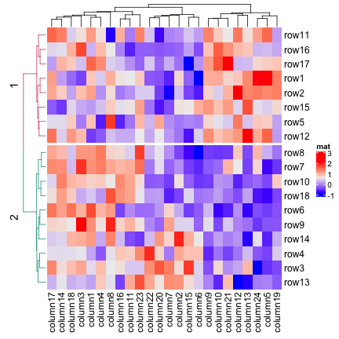

```r
dend = hclust(dist(mat))
dend = color_branches(dend, k = 2)
Heatmap(mat, name = "mat", cluster_rows = dend, row_split = 2)
```

If you want to combine splitting from `cutree()` and other categorical variables, you need to generate the classes from `cutree()` in the first place, append to e.g. `row_split` as a data frame and then send it to `row_split` argument.

```r
# code only for demonstration
split = data.frame(cutree(hclust(dist(mat)), k = 2), rep(c("A", "B"), 9))
Heatmap(mat, name = "mat", row_split = split)
```

### Titles for splitting

When `row_split`/`column_split` is set as a single number, there is only one categorical variable, while when `row_km`/`column_km` is set and/or `row_split`/`column_split` is set as categorical variables, there will be multiple categorical variables. By default, the titlea are in a form of `level1,level2,...` which corresponds to every combination of levels in all categorical variables. The titles for splitting can be controlled by “a title template”.

**ComplexHeatmap** supports three types of templates. The first one is by `sprintf()` where the `%s` is replaced by the corresponding level. In following example, since all combinations of `split` are `A,C`, `A,D`, `B,C` and `B,D`, if `row_title` is set to `%s|%s`, the four row titles will be `A|C`, `A|D`, `B|C`, `B|D`.

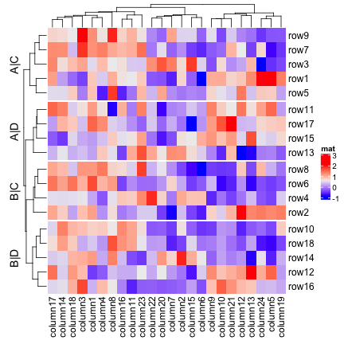

```r
split = data.frame(rep(c("A", "B"), 9), rep(c("C", "D"), each = 9))
Heatmap(mat, name = "mat", row_split = split, row_title = "%s|%s")
```

For the `sprintf()` template, you can only put the levels which are `A,B,C,D` in the title. However, when making the heatmap, you might want to put more meaningful text instead of the internal levels. Once you know how to correspond the text to the level, you can add it by following two template methods.

In the following two template methods, special marks are used to mark the R code which is executable (it is called variable interpolation where the code is extracted and executed and the returned value in put back to the string). There are two types of template marks `@{}` and `{}`. The first one is from **GetoptLong** package which should already be installed when you install the **ComplexHeatmap** package and the second one is from **glue** package which you need to install to support it.

There is an internal variable `x` you should use when you use the latter two templates. `x` is just a simple vector which contains current category levels (e.g. `c("A", "C")`).

```r
# code only for demonstration
map1 = c("A" = "aaa", "B" = "bbb")
map2 = c("C" = "333", "C" = "444")
Heatmap(mat, name = "mat", row_split = split, row_title = "@{x[1]}|@{x[2]}")
Heatmap(mat, name = "mat", row_split = split, row_title = "{x[1]}|{x[2]}")
```

The row title is rotated by default, you can set `row_title_rot = 0` to make it horizontal:

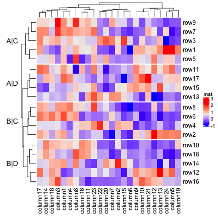

```r
Heatmap(mat, name = "mat", row_split = split, row_title = "%s|%s", row_title_rot = 0)
```

When `row_split`/`column_split` is set as a number, you can also use template to adjust the titles for slices.

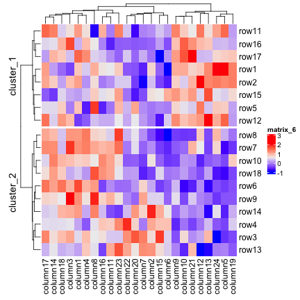

```r
# code only for demonstration
Heatmap(mat, row_split = 2, row_title = "cluster_%s")
```

If you known the final number of row slices, you can directly set a vector of titles to `row_title`. Be careful the number of row slices is not always identical to `nlevel_1*nlevel_2*...`.

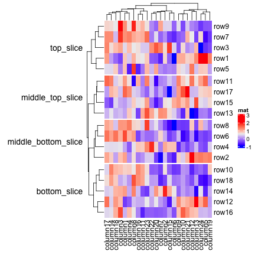

```r
Heatmap(mat, name = "mat", row_split = split,
    row_title = c("top_slice", "middle_top_slice", "middle_bottom_slice", "bottom_slice"),
    row_title_rot = 0)
```

If the length of `row_title` is specified as a single string, it will be like a title for all slices.

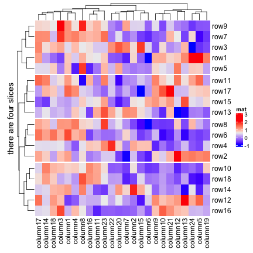

```r
Heatmap(mat, name = "mat", row_split = split, row_title = "there are four slices")
```

If you still want to titles for each slice, but also a global title, you can do as follows.

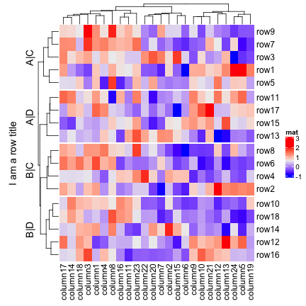

```r
ht = Heatmap(mat, name = "mat", row_split = split, row_title = "%s|%s")
draw(ht, row_title = "I am a row title")
```

Actually the `row_title` used in `draw()` function is the row title of the heatmap list, although in following example there is one heatmap. The `draw()` function and the heatmap list will be introduced in later chapters.

### Gaps between slices

The space of gaps between row/column slices can be controlled by `row_gap`/`column_gap`. The value can be a single unit or a vector of units.

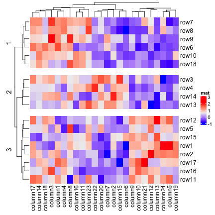

```r
Heatmap(mat, name = "mat", row_km = 3, row_gap = unit(5, "mm"))
```

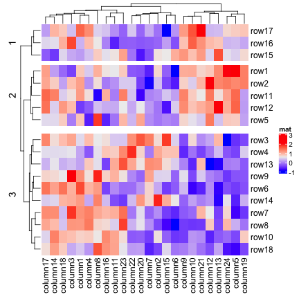

```r
Heatmap(mat, name = "mat", row_km = 3, row_gap = unit(c(2, 4), "mm"))
```

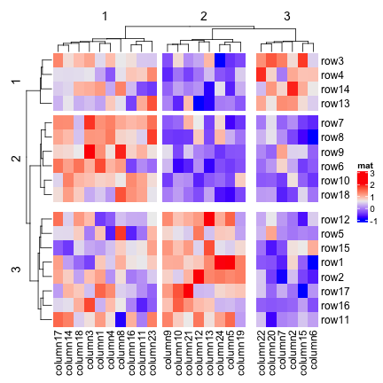

```r
Heatmap(mat, name = "mat", row_km = 3, row_gap = unit(c(2, 4), "mm"),
    column_km = 3, column_gap = unit(c(2, 4), "mm"))
```

When heatmap border is added by setting `border = TRUE`, the border of every slice is added.

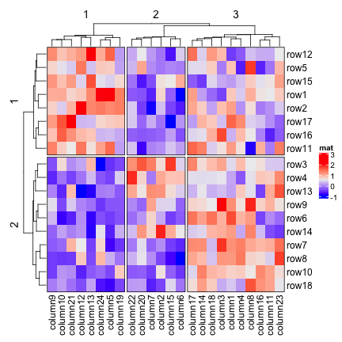

```r
Heatmap(mat, name = "mat", row_km = 2, column_km = 3, border = TRUE)
```

If you set gap size to zero, the heatmap will look like it is partitioned by vertical and horizontal lines.

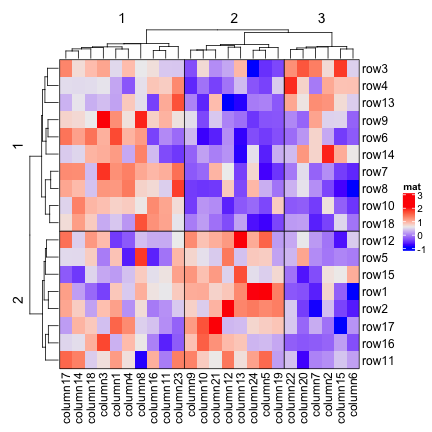

```r
Heatmap(mat, name = "mat", row_km = 2, column_km = 3,
    row_gap = unit(0, "mm"), column_gap = unit(0, "mm"), border = TRUE)
```

### Split the heatmap annotations

The heatmap annotations attached to the heatmap will also be split. Following gives you a simple example and the heatmap annotation will be introduced in later chapters.

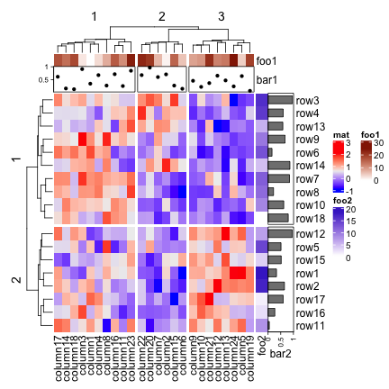

```r
Heatmap(mat, name = "mat", row_km = 2, column_km = 3,
    top_annotation = HeatmapAnnotation(foo1 = 1:24, bar1 = anno_points(runif(24))),
    right_annotation = rowAnnotation(foo2 = 18:1, bar2 = anno_barplot(runif(18)))
)
```

## Heatmap as raster image

Saving plots in PDF format is kind like best parctice to preserve the quality. However, when there are too many rows (say, > 10000), the output PDF file would be huge and it takes long time and memory to read the whole plot. On the other hand, details of the huge matrix will not be seen in limited size of PDF file. Rendering heatmaps (the heatmap body) as raster images will effectively reduce the file size while the plot looks exactly the same for your screen or if you print it out. In `Heatmap()` function, there are four options which control how to generate the raster image: `use_raster`, `raster_device`, `raster_quality`, `raster_device_param`.

You can choose graphic device (`png`, `jpeg` and `tiff`) by `raster_device`, control the quality of the raster image by `raster_quality`, and pass further parameters for a specific device by `raster_device_param`.

If `raster_quality` is set to 1, internally, a PNG (if `raster_device` is set to `png`) file is generated with the same physical size as the heatmap body and refit into the heatmap body as a raster image. The png file generated has the size of `raster_quality*width` and `raster_quality*height`. So a larger `raster_quality` value gives you a better reservation of the original resolution.

In the package, `use_raster` is by default turned on if the number of rows or columns is more than 2000.

```r
# code only for demonstration
Heatmap(mat, use_raster = TRUE, raster_quality = 2)
```

## Customize the heatmap body

The heatmap body can be self-defined to add more types of graphics. By default the heatmap body is composed by an array of rectangles (it is called grids in other parts of this documentation, but it is called “*cells*” here) with different filled colors. However, it is also possible to add more graphics or symbols as additional layers on the heatmap. There are two arguments `cell_fun` and `layer_fun` which both are user-defined functions.

`cell_fun` draws in each cell repeatedly, which is internally executed in two nested `for` loops, while `layer_fun` is the vectorized version of `cell_fun`. `cell_fun` is easier to understand but `layer_fun` is faster to execute.

`cell_fun` expects a function with 7 arguments (the argument names can be different from following, but the order must be the same), which are:

- `j`: column index in the matrix. Column index corresponds to the x-direction in the viewport, that's why `j` is put as the first argument.
- `i`: row index in the matrix.
- `x`: x coordinate of middle point of the cell which is measured in the viewport of the heatmap body.
- `y`: y coordinate of middle point of the cell which is measured in the viewport of the heatmap body.
- `width`: width of the cell. The value is `unit(1/ncol(mat), "npc")`.
- `height`: height of the cell. The value is `unit(1/nrow(mat), "npc")`.
- `fill`: color of the cell.

The values for the seven arguments are automatically sent to the function when executed in each cell.

The most common use is to add values in the matrix onto the heatmap:

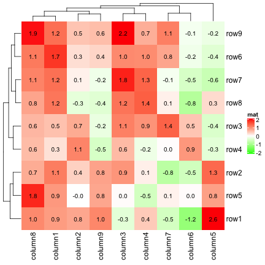

```r
small_mat = mat[1:9, 1:9]
col_fun = colorRamp2(c(-2, 0, 2), c("green", "white", "red"))
Heatmap(small_mat, name = "mat", col = col_fun,
    cell_fun = function(j, i, x, y, width, height, fill) {
        grid.text(sprintf("%.1f", mat[i, j]), x, y, gp = gpar(fontsize = 10))
})
```

and we can also choose only to add text for the cells with positive values:

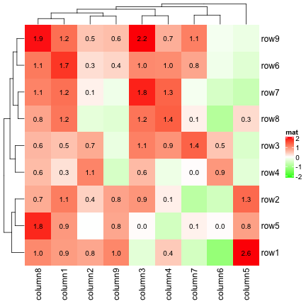

```r
Heatmap(small_mat, name = "mat",  col = col_fun,
    cell_fun = function(j, i, x, y, width, height, fill) {
        if(small_mat[i, j] > 0)
            grid.text(sprintf("%.1f", mat[i, j]), x, y, gp = gpar(fontsize = 10))
})
```

In following example, we make a heatmap which shows correlation matrix similar as the **corrplot** package:

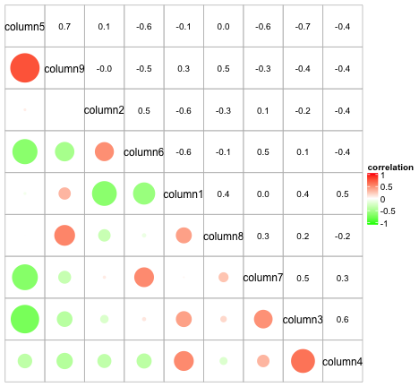

```r
cor_mat = cor(small_mat)
od = hclust(dist(cor_mat))$order
cor_mat = cor_mat[od, od]
nm = rownames(cor_mat)
col_fun = circlize::colorRamp2(c(-1, 0, 1), c("green", "white", "red"))
# `col = col_fun` here is used to generate the legend
Heatmap(cor_mat, name = "correlation", col = col_fun, rect_gp = gpar(type = "none"),
    cell_fun = function(j, i, x, y, width, height, fill) {
        grid.rect(x = x, y = y, width = width, height = height, gp = gpar(col = "grey", fill = NA))
        if(i == j) {
            grid.text(nm[i], x = x, y = y)
        } else if(i > j) {
            grid.circle(x = x, y = y, r = abs(cor_mat[i, j])/2 * min(unit.c(width, height)),
                gp = gpar(fill = col_fun(cor_mat[i, j]), col = NA))
        } else {
            grid.text(sprintf("%.1f", cor_mat[i, j]), x, y, gp = gpar(fontsize = 10))
        }
    }, cluster_rows = FALSE, cluster_columns = FALSE,
    show_row_names = FALSE, show_column_names = FALSE)
```

Similar as `cell_fun`, `layer_fun` also needs seven arguments, but they are all in vector form:

```r
# code only for demonstration
Heatmap(..., layer_fun = function(j, i, x, y, w, h, fill) {...})
# on you can capitalize the arguments to show they are vectors
Heatmap(..., layer_fun = function(J, I, X, Y, W, H, F) {...})
```

Since `j` and `i` are vectors, to get corresponding values in the matrix, we cannot use the form as `mat[j, i]` because it gives you a matrix with `length(i)` rows and `length(j)` columns, instead we can use `pindex()` function from **ComplexHeatmap** which is like pairwise indexing. See follow example:

```r
mfoo = matrix(1:9, nr = 3)
mfoo[1:2, c(1, 3)]
```

```
##      [,1] [,2]
## [1,]    1    7
## [2,]    2    8
```

```r
# but we actually want mfoo[1, 1] and mfoo[2, 3]
pindex(mfoo, 1:2, c(1, 3))
```

```
## [1] 1 8
```

Next example shows the `layer_fun` version of add text on heatmap. It basically the same as the `cell_fun` version.

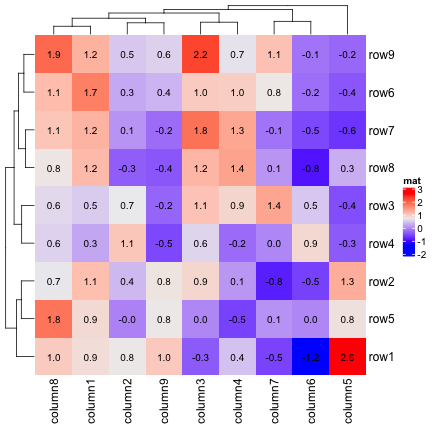

```r
Heatmap(small_mat, name = "mat", layer_fun = function(j, i, x, y, width, height, fill) {
    # since grid.text can also be vectorized
    grid.text(sprintf("%.1f", pindex(mat, i, j)), x, y, gp = gpar(fontsize = 10))
})
```

And only add text to cells with positive values:

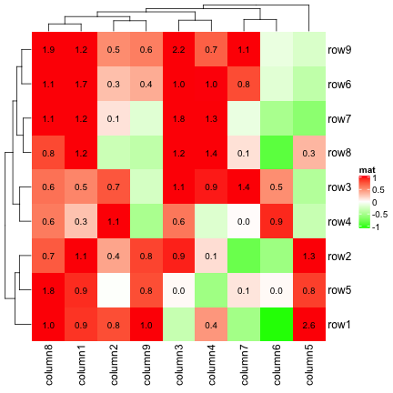

```r
Heatmap(small_mat, name = "mat", col = col_fun,
    layer_fun = function(j, i, x, y, width, height, fill) {
        v = pindex(mat, i, j)
        l = v > 0
        grid.text(sprintf("%.1f", v[l]), x[l], y[l], gp = gpar(fontsize = 10))
})
```

One last example is to visualize a [GO game](https://en.wikipedia.org/wiki/Go_%28game%29). The input data takes records of moves in the game.

```r
str = "B[cp];W[pq];B[dc];W[qd];B[eq];W[od];B[de];W[jc];B[qk];W[qn]
;B[qh];W[ck];B[ci];W[cn];B[hc];W[je];B[jq];W[df];B[ee];W[cf]
;B[ei];W[bc];B[ce];W[be];B[bd];W[cd];B[bf];W[ad];B[bg];W[cc]
;B[eb];W[db];B[ec];W[lq];B[nq];W[jp];B[iq];W[kq];B[pp];W[op]
;B[po];W[oq];B[rp];W[ql];B[oo];W[no];B[pl];W[pm];B[np];W[qq]
;B[om];W[ol];B[pk];W[qp];B[on];W[rm];B[mo];W[nr];B[rl];W[rk]
;B[qm];W[dp];B[dq];W[ql];B[or];W[mp];B[nn];W[mq];B[qm];W[bp]
;B[co];W[ql];B[no];W[pr];B[qm];W[dd];B[pn];W[ed];B[bo];W[eg]
;B[ef];W[dg];B[ge];W[gh];B[gf];W[gg];B[ek];W[ig];B[fd];W[en]
;B[bn];W[ip];B[dm];W[ff];B[cb];W[fe];B[hp];W[ho];B[hq];W[el]
;B[dl];W[fk];B[ej];W[fp];B[go];W[hn];B[fo];W[em];B[dn];W[eo]
;B[gp];W[ib];B[gc];W[pg];B[qg];W[ng];B[qc];W[re];B[pf];W[of]
;B[rc];W[ob];B[ph];W[qo];B[rn];W[mi];B[og];W[oe];B[qe];W[rd]
;B[rf];W[pd];B[gm];W[gl];B[fm];W[fl];B[lj];W[mj];B[lk];W[ro]
;B[hl];W[hk];B[ik];W[dk];B[bi];W[di];B[dj];W[dh];B[hj];W[gj]
;B[li];W[lh];B[kh];W[lg];B[jn];W[do];B[cl];W[ij];B[gk];W[bl]
;B[cm];W[hk];B[jk];W[lo];B[hi];W[hm];B[gk];W[bm];B[cn];W[hk]
;B[il];W[cq];B[bq];W[ii];B[sm];W[jo];B[kn];W[fq];B[ep];W[cj]
;B[bk];W[er];B[cr];W[gr];B[gk];W[fj];B[ko];W[kp];B[hr];W[jr]
;B[nh];W[mh];B[mk];W[bb];B[da];W[jh];B[ic];W[id];B[hb];W[jb]
;B[oj];W[fn];B[fs];W[fr];B[gs];W[es];B[hs];W[gn];B[kr];W[is]
;B[dr];W[fi];B[bj];W[hd];B[gd];W[ln];B[lm];W[oi];B[oh];W[ni]
;B[pi];W[ki];B[kj];W[ji];B[so];W[rq];B[if];W[jf];B[hh];W[hf]
;B[he];W[ie];B[hg];W[ba];B[ca];W[sp];B[im];W[sn];B[rm];W[pe]
;B[qf];W[if];B[hk];W[nj];B[nk];W[lr];B[mn];W[af];B[ag];W[ch]
;B[bh];W[lp];B[ia];W[ja];B[ha];W[sf];B[sg];W[se];B[eh];W[fh]
;B[in];W[ih];B[ae];W[so];B[af]"
```

We convert it into a matrix:

```r
str = gsub("\\n", "", str)
step = strsplit(str, ";")[[1]]
type = gsub("(B|W).*", "\\1", step)
row = gsub("(B|W)\\[(.).\\]", "\\2", step)
column = gsub("(B|W)\\[.(.)\\]", "\\2", step)

go_mat = matrix(nrow = 19, ncol = 19)
rownames(go_mat) = letters[1:19]
colnames(go_mat) = letters[1:19]
for(i in seq_along(row)) {
    go_mat[row[i], column[i]] = type[i]
}
go_mat[1:4, 1:4]
```

```
##   a   b   c   d
## a NA  NA  NA  "W"
## b "W" "W" "W" "B"
## c "B" "B" "W" "W"
## d "B" "W" "B" "W"
```

Black and white stones are put based on the values in the matrix:

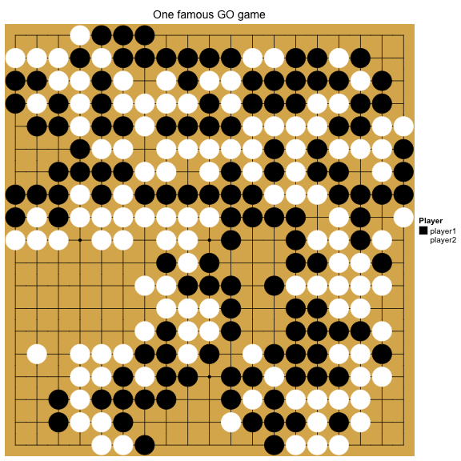

```r
Heatmap(go_mat, name = "go", rect_gp = gpar(type = "none"),
    cell_fun = function(j, i, x, y, w, h, col) {
        grid.rect(x, y, w, h, gp = gpar(fill = "#dcb35c", col = NA))
        if(i == 1) {
            grid.segments(x, y-h*0.5, x, y)
        } else if(i == nrow(go_mat)) {
            grid.segments(x, y, x, y+h*0.5)
        } else {
            grid.segments(x, y-h*0.5, x, y+h*0.5)
        }
        if(j == 1) {
            grid.segments(x, y, x+w*0.5, y)
        } else if(j == ncol(go_mat)) {
            grid.segments(x-w*0.5, y, x, y)
        } else {
            grid.segments(x-w*0.5, y, x+w*0.5, y)
        }

        if(i %in% c(4, 10, 16) & j %in% c(4, 10, 16)) {
            grid.points(x, y, pch = 16, size = unit(2, "mm"))
        }

        r = min(unit.c(w, h))*0.45
        if(is.na(go_mat[i, j])) {
        } else if(go_mat[i, j] == "W") {
            grid.circle(x, y, r, gp = gpar(fill = "white", col = "white"))
        } else if(go_mat[i, j] == "B") {
            grid.circle(x, y, r, gp = gpar(fill = "black", col = "black"))
        }
    },
    col = c("B" = "black", "W" = "white"),
    show_row_names = FALSE, show_column_names = FALSE,
    column_title = "One famous GO game",
    heatmap_legend_param = list(title = "Player", at = c("B", "W"),
        labels = c("player1", "player2"), grid_border = "black")
)
```

## Size of the heatmap

`width`, `heatmap_width`, `height` and `heatmap_height` control the size of the heatmap. By default, all heatmap components have fixed width or height, e.g. the width of row dendrogram is `1cm`. The width or the height of the heatmap body fill the rest area of the final plotting page, which means, if you draw it in an interactive graphic window and you change the size of the window by draging it, the size of the heatmap body is automatically adjusted.

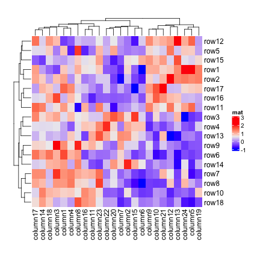

```
## Since all heatmaps/annotations have absolute units, the total width of the plot is 140mm
## Since all heatmaps/annotations have absolute units, the total height of the plot is 135mm
```

```r
Heatmap(mat, name = "mat", width = unit(10, "cm"), height = unit(10, "cm"))
```

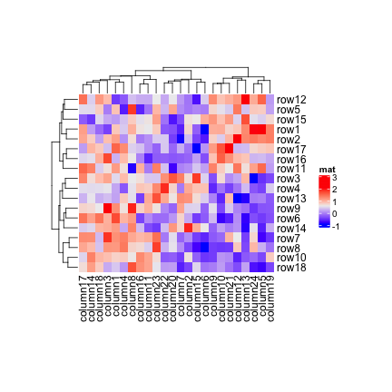

```
## Since all heatmaps/annotations have absolute units, the total width of the plot is 116mm
## Since all heatmaps/annotations have absolute units, the total height of the plot is 104mm
```

```r
Heatmap(mat, name = "mat", heatmap_width = unit(10, "cm"), heatmap_height = unit(10, "cm"))
```

There will be message showing the size of the whole plot.

Finally, the four size arguments are more important when there are a list of heatmaps, which will be introduced later.

## Plot the heatmap

`Heatmap()` function actually is only a constructor, which means it only puts all the data and configurations into the object in the `Heatmap` class. The clustering will only be performed after the `draw()` method is called. Under interactive mode (e.g. the interactive R terminal where you can type your R code line by line), directly calling `Heatmap()` without returning to any object prints the object and the print method (or the S4 `show()` method) for the `Heatmap` class object calls `draw()` internally. So if you type `Heatmap(...)` in your R terminal, it looks like it is a plotting function like `plot()`, you need to be aware of that it is actually not and in the following cases you will see nothing plotted.

- you put `Heatmap(...)` inside a function,
- you put `Heatmap(...)` in a code chunk like `for` or `if-else`
- you put `Heatmap(...)` in an Rscript and you run it under command line.

The reason is in above three cases, the `show()` method WILL NOT be called and thus `draw()` method is not executed either. So, to make the plot, you need to call `draw()` explicitly: `draw(Heatmap(...))` or:

```r
# code only for demonstration
ht = Heatmap(...)
draw(ht)
```

The `draw()` function actually is applied to a list of heatmaps in `HeatmapList` class. The `draw()` method for the single `Heatmap` class constructs a `HeatmapList` with only one heatmap and call `draw()` method of the `HeatmapList` class. The `draw()` function accpets a lot of more arguments which e.g. controls the legends. It will be discussed in later chapters.

```r
draw(ht, heatmap_legend_side, padding, ...)
```

## Get orders and dendrograms

The row/column orders of the heatmap can be obtained by `row_order()`/`column_order()` functions. You can directly apply to the heatmap object returned by `Heatmap()` or to the object returned by `draw()`. In following, we take `row_order()` as example.

```r
small_mat = mat[1:9, 1:9]
ht1 = Heatmap(small_mat)
row_order(ht1)
```

```
## [1] 9 6 7 8 3 4 2 5 1
```

```r
ht2 = draw(ht1)
row_order(ht2)
```

```
## [1] 9 6 7 8 3 4 2 5 1
```

As explained, `Heatmap()` function does not perform clustering, thus, when directly apply `row_order()` on `ht1`, clustering will be performed. Later when making the heatmap by `draw(ht1)`, the clustering will be applied again. This might be a problem that if you set k-means clustering in the heatmap. Since the clustering is applied twice, k-means might give you different clustering, which means, you might have different results from `row_order()` and you might have different heatmap.

In following chunk of code, `o1`, `o2` and `o3` might be different because each time, k-means clustering is performed.

```r
ht1 = Heatmap(small_mat, row_km = 2)
o1 = row_order(ht1)
o2 = row_order(ht1)
ht2 = draw(ht1)
o3 = row_order(ht2)
o4 = row_order(ht2)
```

`draw()` function returns the heatmap (or more precisely, the heatmap list) which has been reordered, and applying `row_order()` just extracts the row order from the object, which ensures the row order is exactly the same as the one shown in the heatmap. In above code, `o3` is always identical to `o4`.

So, the preferable way to get row/column orders is as follows.

```r
# code only for demonstration
ht = Heatmap(small_mat)
ht = draw(ht)
row_order(ht)
column_order(ht)
```

If rows/columns are split, row order or column order will be a list.

```r
ht = Heatmap(small_mat, row_km = 2, column_km = 3)
ht = draw(ht)
row_order(ht)
```

```
## $`1`
## [1] 9 6 7 8 3 4
##
## $`2`
## [1] 2 5 1
```

```r
column_order(ht)
```

```
## $`1`
## [1] 5 9
##
## $`2`
## [1] 8 1 3 4
##
## $`3`
## [1] 2 7 6
```

Similarly, the `row_dend()`/`column_dend()` functions return the dendrograms. It returns a single dendrogram or a list of dendrograms depending on whether the heatmap is split.

```r
ht = Heatmap(small_mat, row_km = 2)
ht = draw(ht)
row_dend(ht)
```

[output not shown]

```r
column_dend(ht)
```

```
## --[dendrogram w/ 2 branches and 9 members at h = 5.19]
##   |--[dendrogram w/ 2 branches and 8 members at h = 4.49]
##   |  |--[dendrogram w/ 2 branches and 6 members at h = 3.85]
##   |  |  |--[dendrogram w/ 2 branches and 4 members at h = 2.9]
##   |  |  |  |--[dendrogram w/ 2 branches and 2 members at h = 1.43]
##   |  |  |  |  |--leaf "column8" ( value.column8 = -1.06, x = 0.5 )
##   |  |  |  |  `--leaf "column1" ( value.column1 = -0.995, x = 1.5 )
##   |  |  |  `--[dendrogram w/ 2 branches and 2 members at h = 2.05]
##   |  |  |     |--leaf "column2" ( value.column2 = -0.389, x = 2.5 )
##   |  |  |     `--leaf "column9" ( value.column9 = -0.248, x = 3.5 )
##   |  |  `--[dendrogram w/ 2 branches and 2 members at h = 2.17]
##   |  |     |--leaf "column3" ( value.column3 = -0.943, x = 4.5 )
##   |  |     `--leaf "column4" ( value.column4 = -0.575, x = 5.5 )
##   |  `--[dendrogram w/ 2 branches and 2 members at h = 2.33]
##   |     |--leaf "column7" ( value.column7 = -0.229, x = 6.5 )
##   |     `--leaf "column6" ( value.column6 = 0.21, x = 7.5 )
##   `--leaf "column5" ( value.column5 = -0.342, x = 8.5 )
```

## Subset a heatmap

Since heatmap is a representation of a matrix, there is also subset methods for the `Heatmap` class.

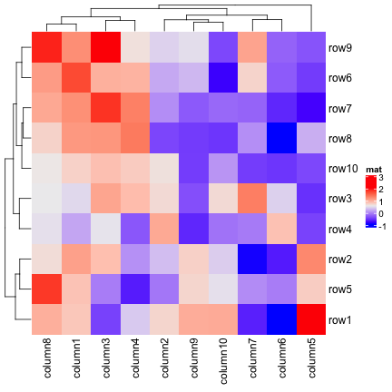

```r
ht = Heatmap(mat, name = "mat")
ht[1:10, 1:10]
```

The subset method only do subsetting on the matrix and heatmap components, some of the arguments should not be set such as `cluster_rows` as a `dendrogram` object when you want to do subsetting.

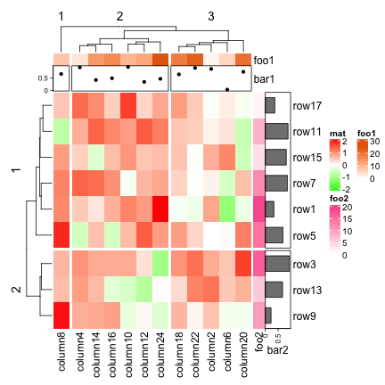

```r
ht = Heatmap(mat, name = "mat", row_km = 2, column_km = 3,
    col = colorRamp2(c(-2, 0, 2), c("green", "white", "red")),
    top_annotation = HeatmapAnnotation(foo1 = 1:24, bar1 = anno_points(runif(24))),
    right_annotation = rowAnnotation(foo2 = 18:1, bar2 = anno_barplot(runif(18)))
)
ht[1:9*2 - 1, 1:12*2] # odd rows, even columns
```

The implementation of subsetting heatmaps is very experimental. If you have problems or comments, please let me know.